# R Notebook

```r
library(tidyverse)
library(GGally)
library(dplyr)
```

#Tidy up the data ready for regression:

#* You might like to think about removing some or all of `date`, `id`, `sqft_living15`, `sqft_lot15` and `zipcode` (`lat` and `long` provide a better measure of location in any event). * Have a think about how to treat `waterfront`. Should we convert its type? * We converted `yr_renovated` into a `renovated` logical variable, indicating whether the property had ever been renovated. You may wish to do the same. * Have a think about how to treat `condition` and `grade`? Are they interval or categorical ordinal data types?

```r
 sale_house<- read_csv("kc_house_data.csv")
```

```r
glimpse(sale_house)
```

```
Rows: 21,613
Columns: 21
$ id            <chr> "7129300520", "6414100192", "563150…
$ date          <dttm> 2014-10-13, 2014-12-09, 2015-02-25…
$ price         <dbl> 221900, 538000, 180000, 604000, 510…
$ bedrooms      <dbl> 3, 3, 2, 4, 3, 4, 3, 3, 3, 3, 3, 2,…
$ bathrooms     <dbl> 1.00, 2.25, 1.00, 3.00, 2.00, 4.50,…
$ sqft_living   <dbl> 1180, 2570, 770, 1960, 1680, 5420, …
$ sqft_lot      <dbl> 5650, 7242, 10000, 5000, 8080, 1019…
$ floors        <dbl> 1.0, 2.0, 1.0, 1.0, 1.0, 1.0, 2.0, …
$ waterfront    <dbl> 0, 0, 0, 0, 0, 0, 0, 0, 0, 0, 0, 0,…
$ view          <dbl> 0, 0, 0, 0, 0, 0, 0, 0, 0, 0, 0, 0,…
$ condition     <dbl> 3, 3, 3, 5, 3, 3, 3, 3, 3, 3, 3, 4,…
$ grade         <dbl> 7, 7, 6, 7, 8, 11, 7, 7, 7, 7, 8, 7…
$ sqft_above    <dbl> 1180, 2170, 770, 1050, 1680, 3890, …
$ sqft_basement <dbl> 0, 400, 0, 910, 0, 1530, 0, 0, 730,…
$ yr_built      <dbl> 1955, 1951, 1933, 1965, 1987, 2001,…
$ yr_renovated  <dbl> 0, 1991, 0, 0, 0, 0, 0, 0, 0, 0, 0,…
$ zipcode       <dbl> 98178, 98125, 98028, 98136, 98074, …
$ lat           <dbl> 47.5112, 47.7210, 47.7379, 47.5208,…
$ long          <dbl> -122.257, -122.319, -122.233, -122.…
$ sqft_living15 <dbl> 1340, 1690, 2720, 1360, 1800, 4760,…
$ sqft_lot15    <dbl> 5650, 7639, 8062, 5000, 7503, 10193…
```

```r
library(GGally)
```

```r
head(sale_house)
```

| id | date | price | bedrooms | bathrooms | sqft_living | sqft_lot | floors | waterfront | view | condition | grade | sqft_above | sqft_basement | yr_built | yr_renovated | zipcode | lat | long | sqft_living15 | sqft_lot15 |
| --- | --- | --- | --- | --- | --- | --- | --- | --- | --- | --- | --- | --- | --- | --- | --- | --- | --- | --- | --- | --- |
| 7129300520 | 2014-10-13 | 221900 | 3 | 1.00 | 1180 | 5650 | 1 | 0 | 0 | 3 | 7 | 1180 | 0 | 1955 | 0 | 98178 | 47.5112 | -122.257 | 1340 | 5650 |
| 6414100192 | 2014-12-09 | 538000 | 3 | 2.25 | 2570 | 7242 | 2 | 0 | 0 | 3 | 7 | 2170 | 400 | 1951 | 1991 | 98125 | 47.7210 | -122.319 | 1690 | 7639 |
| 5631500400 | 2015-02-25 | 180000 | 2 | 1.00 | 770 | 10000 | 1 | 0 | 0 | 3 | 6 | 770 | 0 | 1933 | 0 | 98028 | 47.7379 | -122.233 | 2720 | 8062 |
| 2487200875 | 2014-12-09 | 604000 | 4 | 3.00 | 1960 | 5000 | 1 | 0 | 0 | 5 | 7 | 1050 | 910 | 1965 | 0 | 98136 | 47.5208 | -122.393 | 1360 | 5000 |
| 1954400510 | 2015-02-18 | 510000 | 3 | 2.00 | 1680 | 8080 | 1 | 0 | 0 | 3 | 8 | 1680 | 0 | 1987 | 0 | 98074 | 47.6168 | -122.045 | 1800 | 7503 |
| 7237550310 | 2014-05-12 | 1225000 | 4 | 4.50 | 5420 | 101930 | 1 | 0 | 0 | 3 | 11 | 3890 | 1530 | 2001 | 0 | 98053 | 47.6561 | -122.005 | 4760 | 101930 |

#Tidy up the data ready for regression:

```r
house_clean<- sale_house %>%
  select(-c("id", "date", "sqft_living15", "sqft_lot15", "zipcode"))
```

```r
class(house_clean)
```

```
[1] "tbl_df"     "tbl"        "data.frame"
```

```r
glimpse(house_clean)
```

```
Rows: 21,613
Columns: 16
$ price         <dbl> 221900, 538000, 180000, 604000, 510000, 1225000, 257500, 29…
$ bedrooms      <dbl> 3, 3, 2, 4, 3, 4, 3, 3, 3, 3, 3, 2, 3, 3, 5, 4, 3, 4, 2, 3,…
$ bathrooms     <dbl> 1.00, 2.25, 1.00, 3.00, 2.00, 4.50, 2.25, 1.50, 1.00, 2.50,…
$ sqft_living   <dbl> 1180, 2570, 770, 1960, 1680, 5420, 1715, 1060, 1780, 1890, …
$ sqft_lot      <dbl> 5650, 7242, 10000, 5000, 8080, 101930, 6819, 9711, 7470, 65…
$ floors        <dbl> 1.0, 2.0, 1.0, 1.0, 1.0, 1.0, 2.0, 1.0, 1.0, 2.0, 1.0, 1.0,…
$ waterfront    <dbl> 0, 0, 0, 0, 0, 0, 0, 0, 0, 0, 0, 0, 0, 0, 0, 0, 0, 0, 0, 0,…
$ view          <dbl> 0, 0, 0, 0, 0, 0, 0, 0, 0, 0, 0, 0, 0, 0, 0, 3, 0, 0, 0, 0,…
$ condition     <dbl> 3, 3, 3, 5, 3, 3, 3, 3, 3, 3, 3, 4, 4, 4, 3, 3, 3, 4, 4, 4,…
$ grade         <dbl> 7, 7, 6, 7, 8, 11, 7, 7, 7, 7, 8, 7, 7, 7, 7, 9, 7, 7, 7, 7…
$ sqft_above    <dbl> 1180, 2170, 770, 1050, 1680, 3890, 1715, 1060, 1050, 1890, …
$ sqft_basement <dbl> 0, 400, 0, 910, 0, 1530, 0, 0, 730, 0, 1700, 300, 0, 0, 0, …
$ yr_built      <dbl> 1955, 1951, 1933, 1965, 1987, 2001, 1995, 1963, 1960, 2003,…
$ yr_renovated  <dbl> 0, 1991, 0, 0, 0, 0, 0, 0, 0, 0, 0, 0, 0, 0, 0, 0, 0, 0, 0,…
$ lat           <dbl> 47.5112, 47.7210, 47.7379, 47.5208, 47.6168, 47.6561, 47.30…
$ long          <dbl> -122.257, -122.319, -122.233, -122.393, -122.045, -122.005,…
```

```r
waterfront = as.logical(waterfront))
```

```
Error: unexpected ')' in "waterfront = as.logical(waterfront))"
```

```r
house_clean %>%
mutate(waterfront= as.logical(waterfront)) %>%
  mutate(yr_renovated = yr_renovated >= 0)
```

| price | bedrooms | bathrooms | sqft_living | sqft_lot | floors | waterfront | view | condition | grade | sqft_above | sqft_basement | yr_built | yr_renovated | lat | long |
| --- | --- | --- | --- | --- | --- | --- | --- | --- | --- | --- | --- | --- | --- | --- | --- |
| 221900 | 3 | 1.00 | 1180 | 5650 | 1.0 | FALSE | 0 | 3 | 7 | 1180 | 0 | 1955 | TRUE | 47.5112 | -122.257 |
| 538000 | 3 | 2.25 | 2570 | 7242 | 2.0 | FALSE | 0 | 3 | 7 | 2170 | 400 | 1951 | TRUE | 47.7210 | -122.319 |
| 180000 | 2 | 1.00 | 770 | 10000 | 1.0 | FALSE | 0 | 3 | 6 | 770 | 0 | 1933 | TRUE | 47.7379 | -122.233 |
| 604000 | 4 | 3.00 | 1960 | 5000 | 1.0 | FALSE | 0 | 5 | 7 | 1050 | 910 | 1965 | TRUE | 47.5208 | -122.393 |
| 510000 | 3 | 2.00 | 1680 | 8080 | 1.0 | FALSE | 0 | 3 | 8 | 1680 | 0 | 1987 | TRUE | 47.6168 | -122.045 |
| 1225000 | 4 | 4.50 | 5420 | 101930 | 1.0 | FALSE | 0 | 3 | 11 | 3890 | 1530 | 2001 | TRUE | 47.6561 | -122.005 |
| 257500 | 3 | 2.25 | 1715 | 6819 | 2.0 | FALSE | 0 | 3 | 7 | 1715 | 0 | 1995 | TRUE | 47.3097 | -122.327 |
| 291850 | 3 | 1.50 | 1060 | 9711 | 1.0 | FALSE | 0 | 3 | 7 | 1060 | 0 | 1963 | TRUE | 47.4095 | -122.315 |
| 229500 | 3 | 1.00 | 1780 | 7470 | 1.0 | FALSE | 0 | 3 | 7 | 1050 | 730 | 1960 | TRUE | 47.5123 | -122.337 |
| 323000 | 3 | 2.50 | 1890 | 6560 | 2.0 | FALSE | 0 | 3 | 7 | 1890 | 0 | 2003 | TRUE | 47.3684 | -122.031 |

[output cut: 990 more lines]

#Check for aliased variables using the alias() function (this takes in a formula object and a data set). [Hint - formula price ~ . says ‘price varying with all predictors’, this is a suitable input to alias()]. Remove variables that lead to an alias. Check the ‘Elements of multiple regression’ lesson for a dropdown containing further information on finding aliased variables in a dataset.

```r
library(MASS)
alias(price ~ ., data = house_clean)
```

```
Model :
price ~ bedrooms + bathrooms + sqft_living + sqft_lot + floors +
    waterfront + view + condition + grade + sqft_above + sqft_basement +
    yr_built + yr_renovated + lat + long

Complete :
              (Intercept) bedrooms bathrooms sqft_living
sqft_basement  0           0        0         1
              sqft_lot floors waterfront view condition
sqft_basement  0        0      0          0    0
              grade sqft_above yr_built yr_renovated lat
sqft_basement  0    -1          0        0            0
              long
sqft_basement  0
```

#Remove variables that lead to an alias

```r
library(modelr)
```

```r
  select(house_clean, -c("sqft_living"))
```

```
Error in select(house_clean, -c("sqft_living")) :
  unused argument (-c("sqft_living"))
```

```r
house_clean_numeric <- house_clean %>%
  select_if(is.numeric)
```

```r
houses_clean_nonnumeric <- house_clean %>%
  select_if(function(x) !is.numeric(x))

houses_clean_nonnumeric$price <- house_clean$price
```

[output not shown]

[output cut: 201 more lines]

[output not shown]

[figure not shown]

```r
ggpairs(house_clean_numeric)
```

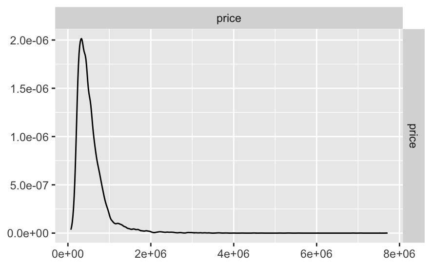

```r
ggpairs(houses_clean_nonnumeric)
```

```r
anova(houses_clean_numeric)
```

```
Error in UseMethod("anova") :
  no applicable method for 'anova' applied to an object of class "c('tbl_df', 'tbl', 'data.frame')"
```

```r
house_clean %>%
  ggplot(aes(x = ))
```